# Joseph Colton’s CS 670 Project

Initialize by loading the required libraries, set the working directory to find the data files, then import the data files. Data Frames are later combined for plots and predictions.

```r
# Load libraries
library(stringr)
library(caret)
library(rsq)

setwd("C:/Users/josep/My Drive/Education/classes/cs670-winter2023/project/data")
#setwd("C:/Users/Joseph/Google Drive/Education/classes/cs670-winter2023/project/data")
# setwd(choose.dir())
infantMortality <- read.csv("infantMortalityRate.csv")
skilledBirth <- read.csv("birthAttendedBySkilledPersonal.csv")
nursingAndMidwife <- read.csv("nursingAndMidwife.csv")

alcoholAbuse <- read.csv("alcoholSubstanceAbuse.csv")
basicSanitization <- read.csv("atLeastBasicSanitizationServices.csv")
drinkingWater <- read.csv("basicDrinkingWaterServices.csv")
handWashing <- read.csv("basicHandWashing.csv")
violence <- read.csv("eliminateViolenceAgainstWomen.csv")
safelySanitization <- read.csv("safelySanitization.csv")
tobacco <- read.csv("tobaccoAge15.csv")

# Clean data
infantMortality$InfantMortRate <- sub(" \\[\\d*\\.*\\d*-\\d*\\.*\\d*\\]", "", infantMortality$InfantMortRate)
```

# **Data**

My wife works at Peace Health Sacred Heard Medical Center at River Bend in the Mom/Baby unit and sometimes in the NICU. I am regularly hearing about challenges related to birth and complications. My wife and I sometimes talk about the idea of her going to a foreign country to do one of the doctors without borders types of trips. I decided that looking into infant mortality and possible causes might be interesting.

I logged into Kaggle and used a data set from Utkarsh S, who goes by the username/handle of Zeus. It appears that this is one of three data sets that he contributed. Originally, I was under the impression that the data sets on Kaggle were curated by the Kaggle organization, but now, it appears that the data sets are more like getting code and projects from GitHub.

The dataset I used was called the “World Health Statistics 2020”. It seems that Zeus collected the data from the World Health Organization, but he does not directly state it in his data card. If I were to do this project all over again, I would probably gather the data from the World Health Organization site myself and clean it up myself.

I selected 10 CSV files from the data set and downloaded them. Each CSV file consists of a location (ie. country), and period (ie. year), an indicator describing the data, and a statistic. There are sometimes additional pieces of information that are used to break up the data. Much of the data had column descriptions that were not very useful, so I renamed the column headings. There were a few pieces of data that could not be used as is, so I had to write R regular expressions to remove extra data.

I used the following CSV files:

alcoholSubstanceAbuse.csv - Location, Year, Indicator, Dim1, AlcoholPercent

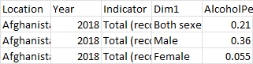

atLeastBasicSanitizationServices.csv - Location, Indicator, Year, Dim1, BasicSaniPercent

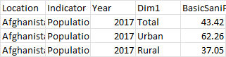

basicDrinkingWaterServices.csv - Location, Year, Indicator, DrinkingWaterPercent

basicHandWashing.csv - Location, Indicator, Year, Dim1, HomeHandWashPercent

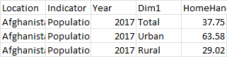

birthAttendedBySkilledPersonal.csv - Location, Year, Indicator, SkilledBirthPercent

eliminateViolenceAgainstWomen.csv - Location, Year, Indicator, Dim1, Dim2, ViolencePercent

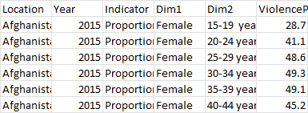

infantMortalityRate.csv - Location, Yearm Indicator, Dim1, InfantMortRate

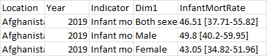

nursingAndMidwife.csv - Location, Year, Indicator, NursingPersonnel

safelySanitization.csv - Location, Indicator, Year, Dim1, SafeSaniPercent

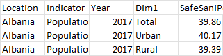

tobaccoAge15.csv - Location, Indicator, Year, Dim1, TobaccoPercent

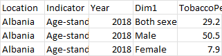

# Questions

Through all of this research, I had a large question and some smaller questions that I decided to ask. My interest is in infant mortality. The main question is how to prevent it. But in order to do that, I decided to look at different suspicions to see what kind of correlation exists. Finally, I wanted to try using related data to see if I could predict infant mortality. Ideally, if the source of infant mortality is identified, we could then potentially make changes to make like better for the babies.

- How can we reduce infant mortality?
- Does the presence of nurses and midwives correlate with infant mortality?
- What basic health needs correlate with infant mortality?
- Do alcohol, tobacco, and violence correlate with infant mortality?

Using the data available I would like to see what patterns I can identify and which predictors seem to correlate with infant mortality.

# Visualization

## **Birth and Medical Personal**

I wanted to see what role the presence of medical personal in the country as well as actually attending the birth played in longer term infant mortality.

**Births Attended by Skilled Personnel**

I wanted to see if having skilled personnel played a role in infant mortality. It appears that as the percent of skilled personnel drops, infant mortality rises. This indicates a definite correlation with infant mortality.

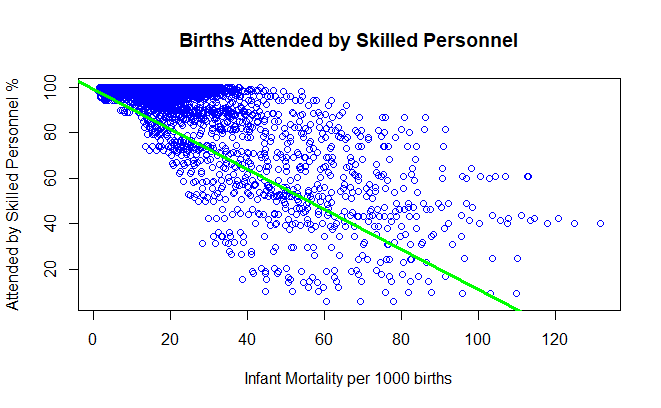

```r
data <- merge(subset(infantMortality, select=-c(Indicator)),
              subset(skilledBirth, select=-c(Indicator)),
              by=c("Location", "Year"))

plot(data$InfantMortRate, data$SkilledBirthPercent, main="Births Attended by Skilled Personnel", xlab="Infant Mortality per 1000 births", ylab="Attended by Skilled Personnel %", col="blue")
lm.fit <- lm(InfantMortRate ~ SkilledBirthPercent, data=data)
abline(lm.fit, col="green", lwd=3)
```

**Nursing and Midwifery personnel**

I looked at how the ratio of midwifes and nurses to population played a role in infant mortality. It appears that if the number of midwives and nurses is high, the infant mortality is low. However, when the number is low, the infant mortality is sometimes high and sometimes low. I am now wondering if wealth might play a role in who gets service. It is possible that someone might be in a country with a lot of skilled personnel, but not be able to have them at the birth.

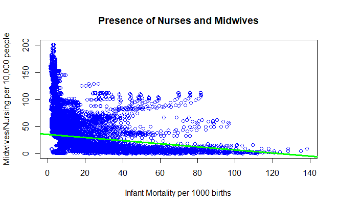

```r
data <- merge(subset(infantMortality, select=-c(Indicator)),
              subset(nursingAndMidwife, select=-c(Indicator)),
              by=c("Location", "Year"))

plot(data$InfantMortRate, data$NursingPersonnel, main="Presence of Nurses and Midwives", xlab="Infant Mortality per 1000 births", ylab="Midwives/Nursing per 10,000 people", col="blue")
lm.fit <- lm(InfantMortRate ~ NursingPersonnel, data=data)
abline(lm.fit, col="green", lwd=3)
```

## **Basic Health Needs**

An area of interest for I wanted to look at was basic health needs. I looked at sanitation, access to clean drinking water, hand washing, and safely managed sanitation services. It appears that all of these are important and help an infant survive.

**Basic Level of Sanitation**

The first plot shows the correlation between basic sanitation in the population and infant mortality. This shows that as the basic sanitation rates drop, the infant mortality rate rises.

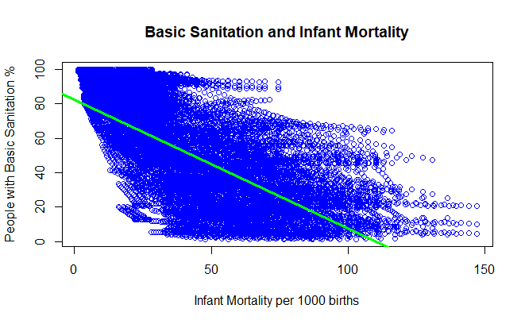

```r
data <- merge(subset(infantMortality, select=-c(Indicator)),
              subset(basicSanitization, select=-c(Indicator)),
              by=c("Location", "Year"))

plot(data$InfantMortRate, data$BasicSaniPercent, main="Basic Sanitation and Infant Mortality", xlab="Infant Mortality per 1000 births", ylab="People with Basic Sanitation %", col="blue")
lm.fit <- lm(InfantMortRate ~ BasicSaniPercent, data=data)
abline(lm.fit, col="green", lwd=3)
```

**Access to Clean Drinking Water**

In addition to sanitation, access to clean drinking water appears to be correlated with infant mortality. As the percent of people with access to clean drinking water goes up, the infant mortality rate drops.

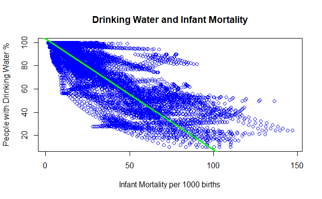

```r
data <- merge(subset(infantMortality, select=-c(Indicator)),
              subset(drinkingWater, select=-c(Indicator)),
              by=c("Location", "Year"))

plot(data$InfantMortRate, data$DrinkingWaterPercent, main="Drinking Water and Infant Mortality", xlab="Infant Mortality per 1000 births", ylab="People with Drinking Water %", col="blue")
lm.fit <- lm(InfantMortRate ~ DrinkingWaterPercent, data=data)
abline(lm.fit, col="green", lwd=3)
```

**Access to Hand Washing Facilities in the Home**

Access to hand washing facilities in the home correlates with lower infant mortality rates. This appears to show that when you have access to wash hands, babies have a better chance at life.

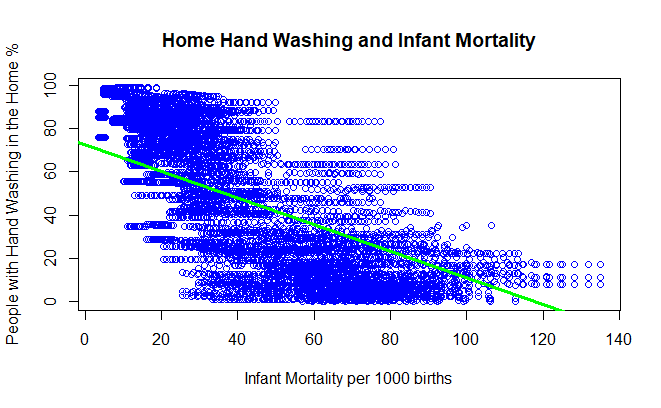

```r
data <- merge(subset(infantMortality, select=-c(Indicator)),
              subset(handWashing, select=-c(Indicator)),
              by=c("Location", "Year"))

plot(data$InfantMortRate, data$HomeHandWashPercent, main="Home Hand Washing and Infant Mortality", xlab="Infant Mortality per 1000 births", ylab="People with Hand Washing in the Home %", col="blue")
lm.fit <- lm(InfantMortRate ~ HomeHandWashPercent, data=data)
abline(lm.fit, col="green", lwd=3)
```

**Managed Safe Sanitation Services**

As people get safely managed sanitation services, the infant mortality rate drops. This indicates that safely managed sanitation services play a positive role in the health of infants.

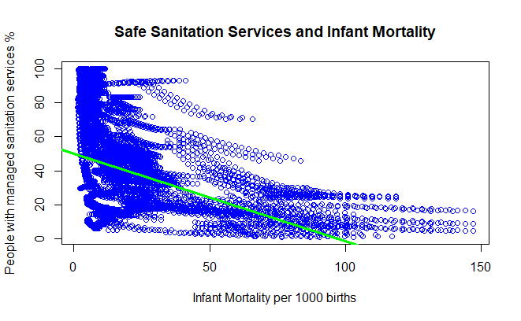

```r
data <- merge(subset(infantMortality, select=-c(Indicator)),
              subset(safelySanitization, select=-c(Indicator)),
              by=c("Location", "Year"))

plot(data$InfantMortRate, data$SafeSaniPercent, main="Safe Sanitation Services and Infant Mortality", xlab="Infant Mortality per 1000 births", ylab="People with managed sanitation services %", col="blue")
lm.fit <- lm(InfantMortRate ~ SafeSaniPercent, data=data)
abline(lm.fit, col="green", lwd=3)
```

## **Drugs and Violence**

After looking at sanitation conditions, I decided to look at drugs use (tobacco, alcohol) and domestic violence against women to see if there are correlations there that might indicate places for possible improvement.

**Alcohol Use**

I wanted to see what role alcohol use might play in infant mortality. I plotted the alcohol use against the infant mortality rate. It appears that with various levels of alcohol consumption, the infant mortality rate does not appear as affected. There is not a lot of information I can gather from this, but it seems that this is not likely a cause of infant mortality.

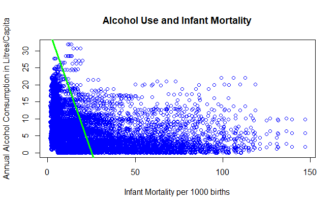

```r
data <- merge(subset(infantMortality, select=-c(Indicator)),
              subset(alcoholAbuse, select=-c(Indicator)),
              by=c("Location", "Year"))

plot(data$InfantMortRate, data$AlcoholPercent, main="Alcohol Use and Infant Mortality", xlab="Infant Mortality per 1000 births", ylab="Annual Alcohol Consumption in Litres/Capita", col="blue")
lm.fit <- lm(InfantMortRate ~ AlcoholPercent, data=data)
abline(lm.fit, col="green", lwd=3)
```

**Tobacco Use**

The next plot shows the affects of tobacco use in the population and the correlation with infant mortality. While visually it does appear that there is a slight correlation between tobacco use and infant mortality, it does not appear to be a strong indicator. There are more likely stronger indicators at play here.

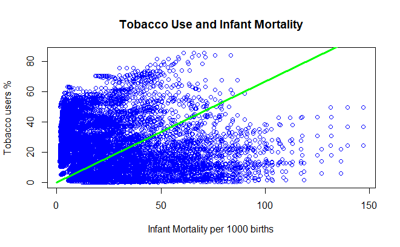

```r
data <- merge(subset(infantMortality, select=-c(Indicator)),
              subset(tobacco, select=-c(Indicator)),
              by=c("Location", "Year"))

plot(data$InfantMortRate, data$TobaccoPercent, main="Tobacco Use and Infant Mortality", xlab="Infant Mortality per 1000 births", ylab="Tobacco users %", col="blue")
lines(y=c(0, 100), x=c(0,150), col="green", lwd=3)
```

**Domestic Violence**

I decided to look and see what role domestic violence against women, by an intimate partner in the last 12 months, in the age range that might be giving birth might play on infant mortality. Interestly, it appears that as the rate of women who experience domestic violence from an intimate partner goes up, so does the infant mortality. This leads me to believe that it is not just women who are experiencing this domestic violence. It is possible that those in these circumstances do not value life as much, or other factors in their environment hurts the survival rate of infants.

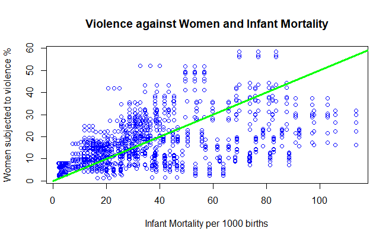

```r
data <- merge(subset(infantMortality, select=-c(Indicator)),
              subset(violence, select=-c(Indicator)),
              by=c("Location", "Year"))

plot(data$InfantMortRate, data$ViolencePercent, main="Violence against Women and Infant Mortality", xlab="Infant Mortality per 1000 births", ylab="Women subjected to violence %", col="blue")
lines(y=c(0, 60), x=c(0,120), col="green", lwd=3)
```

# Models

I decided to train models to predict the infant mortality using the different possible predictors, then compare the results to actual numbers in testing data. I decided to go for a 80/20 split of training/testing data.

**Sanitation/Water Predictions**

First, I decided to look at the sanitation data. One of the problems I ran into is that not every country reported for every year for all 4 of the predictors I decided to use. This means that I was limited to only 172 rows of data. If I were to do this over, I would use interpolated data to fill in gaps and see what I could figure out.

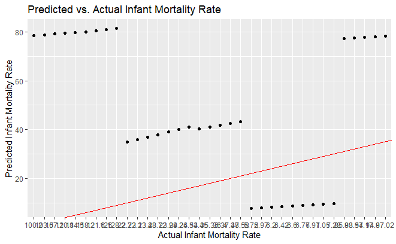

```r
set.seed(0) # Set random number seed
data <- merge(subset(infantMortality[infantMortality$Dim1 == 'Both sexes',], select=-c(Indicator, Dim1)),
              subset(basicSanitization[basicSanitization$Dim1 == 'Total',], select=-c(Indicator, Dim1)),
              by=c("Location", "Year"))
data <- merge(data,
              subset(safelySanitization[safelySanitization$Dim1 == 'Total',], select=-c(Indicator, Dim1)),
              by=c("Location", "Year"))
data <- merge(data,
              subset(drinkingWater, select=-c(Indicator)),
              by=c("Location", "Year"))
data <- merge(data,
              subset(handWashing[handWashing$Dim1 == 'Total',], select=-c(Indicator, Dim1)),
              by=c("Location", "Year"))
data <- subset(data, select=-c(Location, Year))

# Create an 80-20 split of the data
#trainIndex <- createDataPartition(data$InfantMortRate, p = 0.8, list = FALSE)
#training <- data[trainIndex, ]
#testing <- data[-trainIndex, ]
training <- data[0:137,]
testing <- data[138:172,]

# Create a linear model
lm.fit <- lm(InfantMortRate ~ ., data=training)
# summary(lm.fit)

# Make predictions on the testing data
predictions <- predict(lm.fit, newdata = testing)

# Compare predictions to actual values in testing
results <- data.frame(Actual = testing$InfantMortRate, Predicted = predictions)

# Create a scatter plot of predicted vs. actual values
ggplot(results, aes(x = Actual, y = Predicted)) +
  geom_point() +
  geom_abline(intercept = 0, slope = 1, color = "red") +
  labs(x = "Actual Infant Mortality Rate", y = "Predicted Infant Mortality Rate") +
  ggtitle("Predicted vs. Actual Infant Mortality Rate")
```

I decided to see how accurate the predictions were using R-squared.

```r
rsq_lmfit <- rsq(lm.fit)
cat("R-squared for lm.fit:", rsq_lmfit, "\n")
```

```
R-squared for lm.fit: 0.8544228
```

```r
summary(lm.fit)
```

```
Call:
lm(formula = InfantMortRate ~ ., data = training)

Residuals:
     Min       1Q   Median       3Q      Max
-17.8633  -6.2524  -0.8222   5.3099  21.9921

Coefficients:
                     Estimate Std. Error t value Pr(>|t|)
(Intercept)          90.89461    4.54459  20.001  < 2e-16 ***
BasicSaniPercent     -1.07570    0.12599  -8.538 2.86e-14 ***
SafeSaniPercent       0.36114    0.06092   5.928 2.52e-08 ***
DrinkingWaterPercent -0.12489    0.13424  -0.930 0.353889
HomeHandWashPercent   0.24135    0.06965   3.465 0.000715 ***
---
Signif. codes:  0 ‘***’ 0.001 ‘**’ 0.01 ‘*’ 0.05 ‘.’ 0.1 ‘ ’ 1

Residual standard error: 8.739 on 132 degrees of freedom
Multiple R-squared:  0.8544,    Adjusted R-squared:   0.85
F-statistic: 193.7 on 4 and 132 DF,  p-value: < 2.2e-16
```

```r
set.seed(0) # Set random number seed
data <- merge(subset(infantMortality[infantMortality$Dim1 == 'Both sexes',], select=-c(Indicator, Dim1)),
              subset(basicSanitization[basicSanitization$Dim1 == 'Total',], select=-c(Indicator, Dim1)),
              by=c("Location", "Year"))
data <- merge(data,
              subset(safelySanitization[safelySanitization$Dim1 == 'Total',], select=-c(Indicator, Dim1)),
              by=c("Location", "Year"))
data <- subset(data, select=-c(Location, Year))

# Create an 80-20 split of the data
#trainIndex <- createDataPartition(data$InfantMortRate, p = 0.8, list = FALSE)
#training <- data[trainIndex, ]
#testing <- data[-trainIndex, ]
training <- data[0:1132,]
testing <- data[1133:1415,]

# Create a linear model
lm.fit <- lm(InfantMortRate ~ ., data=training)
summary(lm.fit)
```

```
Call:
lm(formula = InfantMortRate ~ ., data = training)

Residuals:
    Min      1Q  Median      3Q     Max
-33.255  -3.233  -0.598   2.748  42.166

Coefficients:
                 Estimate Std. Error t value Pr(>|t|)
(Intercept)      94.66874    1.15494  81.968   <2e-16 ***
BasicSaniPercent -0.88863    0.01688 -52.647   <2e-16 ***
SafeSaniPercent  -0.02451    0.01113  -2.201   0.0279 *
---
Signif. codes:  0 ‘***’ 0.001 ‘**’ 0.01 ‘*’ 0.05 ‘.’ 0.1 ‘ ’ 1

Residual standard error: 8.083 on 1129 degrees of freedom
Multiple R-squared:  0.828, Adjusted R-squared:  0.8277
F-statistic:  2717 on 2 and 1129 DF,  p-value: < 2.2e-16
```

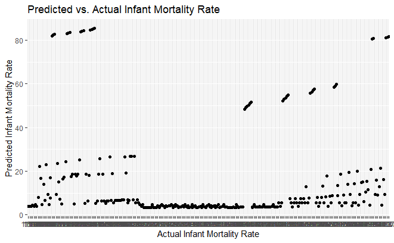

```r
# Make predictions on the testing data
predictions <- predict(lm.fit, newdata = testing)

# Compare predictions to actual values in testing
results <- data.frame(Actual = testing$InfantMortRate, Predicted = predictions)

# Create a scatter plot of predicted vs. actual values
ggplot(results, aes(x = Actual, y = Predicted)) +
  geom_point() +
  labs(x = "Actual Infant Mortality Rate", y = "Predicted Infant Mortality Rate") +
  ggtitle("Predicted vs. Actual Infant Mortality Rate")
```

It really feels like there is something off about the model. The predictions do not seem to like up with expected values. It seems like there are a few countries with numbers that are very off, so I suspect more is going on. Additionally, predictors that seemed to be tightly correlated seem less so now. This might be because we have a lot more values to use in comparisons.

**Skilled Professionals Predictions**

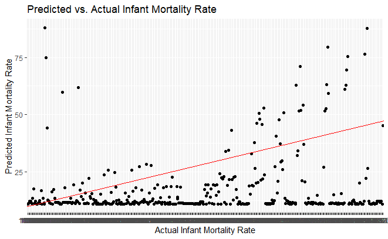

```r
set.seed(0) # Set random number seed
data <- merge(subset(infantMortality[infantMortality$Dim1 == 'Both sexes',], select=-c(Indicator, Dim1)),
              subset(skilledBirth, select=-c(Indicator)),
              by=c("Location", "Year"))
data <- subset(data, select=-c(Location, Year))

# Create an 80-20 split of the data
#trainIndex <- createDataPartition(data$InfantMortRate, p = 0.8, list = FALSE)
#training <- data[trainIndex, ]
#testing <- data[-trainIndex, ]
training <- data[0:1200,]
testing <- data[1201:1596,]

# Create a linear model
lm.fit <- lm(InfantMortRate ~ ., data=training)
# summary(lm.fit)

# Make predictions on the testing data
predictions <- predict(lm.fit, newdata = testing)

# Compare predictions to actual values in testing
results <- data.frame(Actual = testing$InfantMortRate, Predicted = predictions)

# Create a scatter plot of predicted vs. actual values
ggplot(results, aes(x = Actual, y = Predicted)) +
  geom_point() +
  geom_abline(intercept = 10, slope = 0.1, color = "red") +
  labs(x = "Actual Infant Mortality Rate", y = "Predicted Infant Mortality Rate") +
  ggtitle("Predicted vs. Actual Infant Mortality Rate")
```

**Violence against Women**

While the rate at which women experience violence from an intimate partner does not seem like it should correlate with the infant mortality rate, viewing the data earlier appeared to show a correlation, so I decided to try using it to predict the infant mortality rate. I had a lot of missing data, but the data that I did have seemed to do a good job of predicting the infant mortality rate. It would be interesting to see if we could look into causation to see why these two might correlate.

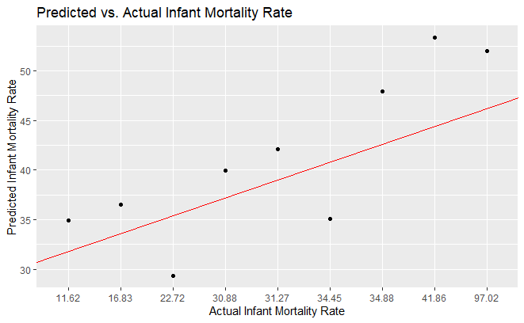

```r
set.seed(0) # Set random number seed
data <- merge(subset(infantMortality[infantMortality$Dim1 == 'Both sexes',], select=-c(Indicator, Dim1)),
              subset(violence[violence$Dim2 == '25-29 years',], select=-c(Indicator)),
              by=c("Location", "Year"))
data <- subset(data, select=-c(Location, Year, Dim1, Dim2))

# Create an 80-20 split of the data
#trainIndex <- createDataPartition(data$InfantMortRate, p = 0.8, list = FALSE)
#training <- data[trainIndex, ]
#testing <- data[-trainIndex, ]
training <- data[0:35,]
testing <- data[36:44,]

# Create a linear model
lm.fit <- lm(InfantMortRate ~ ., data=training)
# summary(lm.fit)

# Make predictions on the testing data
predictions <- predict(lm.fit, newdata = testing)

# Compare predictions to actual values in testing
results <- data.frame(Actual = testing$InfantMortRate, Predicted = predictions)

# Create a scatter plot of predicted vs. actual values
ggplot(results, aes(x = Actual, y = Predicted)) +
  geom_point() +
  geom_abline(intercept = 30, slope = 1.8, color = "red") +
  labs(x = "Actual Infant Mortality Rate", y = "Predicted Infant Mortality Rate") +
  ggtitle("Predicted vs. Actual Infant Mortality Rate")
```

**Combined Predictors**

I decided to combine Skilled Professionals at the birth with the two Sanitation predictors to see if I could get something that better predicted the Infant Mortality Rate. I put a red line at the slope of 1 so that I could see if predictions or actual are higher. It appears that actual numbers are higher. This might indicate some of the predictors have a higher contribution than others.

```r
set.seed(0) # Set random number seed
data <- merge(subset(infantMortality[infantMortality$Dim1 == 'Both sexes',], select=-c(Indicator, Dim1)),
              subset(basicSanitization[basicSanitization$Dim1 == 'Total',], select=-c(Indicator, Dim1)),
              by=c("Location", "Year"))
data <- merge(data,
              subset(safelySanitization[safelySanitization$Dim1 == 'Total',], select=-c(Indicator, Dim1)),
              by=c("Location", "Year"))
data <- merge(data,
              subset(skilledBirth, select=-c(Indicator)),
              by=c("Location", "Year"))
data <- subset(data, select=-c(Location, Year))

# Create an 80-20 split of the data
#trainIndex <- createDataPartition(data$InfantMortRate, p = 0.8, list = FALSE)
#training <- data[trainIndex, ]
#testing <- data[-trainIndex, ]
training <- data[0:684,]
testing <- data[685:856,]

# Create a linear model
lm.fit <- lm(InfantMortRate ~ ., data=training)
summary(lm.fit)
```

```
Call:
lm(formula = InfantMortRate ~ ., data = training)

Residuals:
    Min      1Q  Median      3Q     Max
-21.670  -2.214  -0.588   1.485  31.674

Coefficients:
                    Estimate Std. Error t value Pr(>|t|)
(Intercept)         98.67043    1.87008  52.763  < 2e-16 ***
BasicSaniPercent    -0.38113    0.02990 -12.746  < 2e-16 ***
SafeSaniPercent     -0.06662    0.00972  -6.854 1.61e-11 ***
SkilledBirthPercent -0.51085    0.03124 -16.353  < 2e-16 ***
---
Signif. codes:  0 ‘***’ 0.001 ‘**’ 0.01 ‘*’ 0.05 ‘.’ 0.1 ‘ ’ 1

Residual standard error: 4.917 on 680 degrees of freedom
Multiple R-squared:  0.815, Adjusted R-squared:  0.8142
F-statistic: 998.5 on 3 and 680 DF,  p-value: < 2.2e-16
```

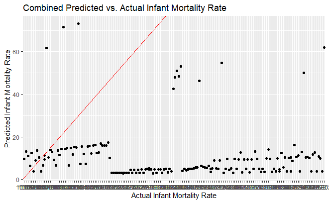

```r
# Make predictions on the testing data
predictions <- predict(lm.fit, newdata = testing)

# Compare predictions to actual values in testing
results <- data.frame(Actual = testing$InfantMortRate, Predicted = predictions)

# Create a scatter plot of predicted vs. actual values
ggplot(results, aes(x = Actual, y = Predicted)) +
  geom_point() +
  geom_abline(intercept = 0, slope = 1, color = "red") +
  labs(x = "Actual Infant Mortality Rate", y = "Predicted Infant Mortality Rate") +
  ggtitle("Combined Predicted vs. Actual Infant Mortality Rate")
```

# Results, Analysis, and Discussion

Looking at all of the data and visuals, I see that infant mortality is a complex issue. Clearly, there are signs that sanitation and clean water is related to infant mortality. If I had unlimited money, I would love to perform an experiment where I built sanitation services and clean water facilities in countries without easy access to these services. I would like to then make sure that people had access to sanitation services and clean water, then see how the infant mortality rate was affected. Either way, an improvement in sanitation services and clean water would be a positive change for some people.

I really thought that alcohol and tobacco use would be good predictors of infant mortality, but it seems that is not the case. While I imagine these are tied to overall life expectancy and death from other causes, it does not appear that they significantly lead to infant mortality. The violence against women numbers showed me something I was not fully expecting. I thought it was possible that women who experienced violence from an intimate partner might also have children that experienced that same violence or they might cause it themselves, but I did not expect it to have such a close correlation. The violence numbers worked as a good predictor for infant mortality, which is a sad thing.

My analysis a fairly limited in that I use linear regression instead of more fitted approaches. It is possible that the numbers could have been better predictors if I had used different models. Another limitation was the source of and quality of data that I was using. I would have liked to have modified the data to fix some of the missing numbers by using estimates.

If I were to do this all over, I would have collected and used more data. I would have liked to see things like education levels and other quality of life indicators such as income/GDP. I would have also liked to look at things like food security, political unrest, and birth/birch control policies.

# Impact

The data seems to tell a certain story. I used the location and year fields to merge data, but this data could be used to tell other political stories. We have to be careful what conclusions are drawn from the data and analysis.

I identified the following places where I would make recommendations in order to improve infant mortality rates in a given country:

1. Governments and businesses should invest in improving sanitation and clean water infrastructure. Improving these makes life better and reduced the infant mortality rates.
2. Governments should encourage more people to become nurses/midwives. They could create training programs and offer scholarships and grants for people in under-served areas who are interested in learning how to become skilled professionals. Then, they should make sure access to skilled professionals is available during pregnancy.
3. Governments should look at law and social practices that might lead to domestic violence. Ideally, governments and society should frown on domestic violence of any sort and discourage it.

While all of these basically focus on government playing a role, it might need to be done by communities or religions.

While I think my models are fairly accurate, it is possible that they are not accurate. Either way, all of the suggestions I suggested are considered positive things in general, so none of the suggestions really has a negative consequence, with possibly the suggestion about domestic violence. If I was wrong, I do not expect the infant mortality rates to raise, most likely, they would be unaffected.